# Projet_Partie2

FRANCK DORONZO, ROMAIN DUDOIT,MARIE VACHET

07/01/2022

## Partie 2

L’objectif est ici d’etudier un cas préesentant un problème de prédiction que ce soit dans le cadre de la régression ou de la catégorisation. Vous devrez pour cela implémenter le code permettant de mettre en oeuvre les points suivants :

— La lecture des données (que vous fournirez avec votre dossier en format .csv ou .xls ou .RData). — Le pré-traitement des données si nécessaire.

— La validation croisée permettant d’évaluer les performances des méthodes suivantes : — Modèle linéaire pénalisé par une fonction de régularisation elasticnet. — Réseau de neuronnes avec une couche cachée. — SVM.

— Autre m´ethode de votre choix sortant des techniques vues en cours (optionel). Pour chaque type de méthode, vous testerez plusieurs ensembles de paramètres.

— Des graphiques permettant de comparer les résultats de chaque méthode avec les différents paramètres utilisés. — Des graphiques permettant de comparer les meilleurs modèles des trois types de méthodes.

## Lecture des données

Notre jeu de données porte sur les haricots secs.

Il comporte 13 611 observations (grains) pour 7 espèces différentes sur lesquelles nous souhaitons faire de la classification.

Les données ont été obtenues après des étapes de segmentation et d’extraction de caractéristiques sur des images prises par un système de vision par ordinateur utilisant une caméra haute résolution.

Les variables explicatives sont au nombre de 16 et sont relatives aux caractéristiques des grains :

1.) Area (A): La surface d’une zone de haricot et le nombre de pixels à l’intérieur de ses limites.

2.) Perimeter (P): La circonférence d’un haricot est définie comme la longueur de sa bordure.

3.) Major axis length (L): La distance entre les extrémités de la ligne la plus longue qui peut être tracée à partir d’un haricot.

4.) Minor axis length (l): La plus longue ligne que l’on peut tracer à partir d’un haricot en étant perpendiculaire à l’axe principal.

5.) Aspect ratio (K): Définit la relation entre L et l.

6.) Eccentricity (Ec): Excentricité de l’ellipse ayant les mêmes moments que la région.

7.) Convex area (C): Nombre de pixels dans le plus petit polygone convexe qui peut contenir la surface d’une graine de haricot.

8.) Equivalent diameter (Ed): Le diamètre d’un cercle ayant la même surface que celle d’une graine de haricot.

9.) Extent (Ex): Le rapport entre les pixels de la boîte englobante et la surface du haricot.

10.) Solidity (S): Le rapport entre les pixels de la coquille convexe et ceux que l’on trouve dans les haricots.

11.) Roundness (R): Calculée à l’aide de la formule suivante : (4piA)/(P^2)

12.)Compactness (CO): Mesure la rondeur d’un objet : Ed/L

13.)ShapeFactor1 (SF1) = L/A

14.)ShapeFactor2 (SF2) = l/A

15.)ShapeFactor3 (SF3)

16.)ShapeFactor4 (SF4)

17.) Class (Seker, Barbunya, Bombay, Cali, Dermosan, Horoz and Sira)

```r
data = read.xlsx('Dry_Bean_Dataset.xlsx',sheetIndex = 1,stringsAsFactors=TRUE)
```

|  | Area | Perimeter | MajorAxisLength | MinorAxisLength | AspectRation | Eccentricity | ConvexArea | EquivDiameter | Extent | Solidity | roundness | Compactness | ShapeFactor1 | ShapeFactor2 | ShapeFactor3 | ShapeFactor4 | Class |
| --- | --- | --- | --- | --- | --- | --- | --- | --- | --- | --- | --- | --- | --- | --- | --- | --- | --- |
| 1 | 28395 | 610.291 | 208.1781 | 173.8887 | 1.197191 | 0.5498122 | 28715 | 190.1411 | 0.7639225 | 0.9888560 | 0.9580271 | 0.9133578 | 0.007331506 | 0.003147289 | 0.8342224 | 0.9987239 | SEKER |
| 2 | 28734 | 638.018 | 200.5248 | 182.7344 | 1.097356 | 0.4117853 | 29172 | 191.2728 | 0.7839681 | 0.9849856 | 0.8870336 | 0.9538608 | 0.006978659 | 0.003563624 | 0.9098505 | 0.9984303 | SEKER |
| 3 | 29380 | 624.110 | 212.8261 | 175.9311 | 1.209713 | 0.5627273 | 29690 | 193.4109 | 0.7781132 | 0.9895588 | 0.9478495 | 0.9087742 | 0.007243912 | 0.003047733 | 0.8258706 | 0.9990661 | SEKER |
| 4 | 30008 | 645.884 | 210.5580 | 182.5165 | 1.153638 | 0.4986160 | 30724 | 195.4671 | 0.7826813 | 0.9766957 | 0.9039364 | 0.9283288 | 0.007016729 | 0.003214562 | 0.8617944 | 0.9941988 | SEKER |
| 5 | 30140 | 620.134 | 201.8479 | 190.2793 | 1.060798 | 0.3336797 | 30417 | 195.8965 | 0.7730980 | 0.9908933 | 0.9848771 | 0.9705155 | 0.006697010 | 0.003664972 | 0.9419004 | 0.9991661 | SEKER |
| 6 | 30279 | 634.927 | 212.5606 | 181.5102 | 1.171067 | 0.5204007 | 30600 | 196.3477 | 0.7756885 | 0.9895098 | 0.9438518 | 0.9237260 | 0.007020065 | 0.003152779 | 0.8532696 | 0.9992358 | SEKER |

```r
dim(data)
```

```
## [1] 13611    17
```

```r
summary(data)
```

```
##       Area          Perimeter      MajorAxisLength MinorAxisLength
##  Min.   : 20420   Min.   : 524.7   Min.   :183.6   Min.   :122.5
##  1st Qu.: 36328   1st Qu.: 703.5   1st Qu.:253.3   1st Qu.:175.8
##  Median : 44652   Median : 794.9   Median :296.9   Median :192.4
##  Mean   : 53048   Mean   : 855.3   Mean   :320.1   Mean   :202.3
##  3rd Qu.: 61332   3rd Qu.: 977.2   3rd Qu.:376.5   3rd Qu.:217.0
##  Max.   :254616   Max.   :1985.4   Max.   :738.9   Max.   :460.2
##
##   AspectRation    Eccentricity      ConvexArea     EquivDiameter
##  Min.   :1.025   Min.   :0.2190   Min.   : 20684   Min.   :161.2
##  1st Qu.:1.432   1st Qu.:0.7159   1st Qu.: 36715   1st Qu.:215.1
##  Median :1.551   Median :0.7644   Median : 45178   Median :238.4
##  Mean   :1.583   Mean   :0.7509   Mean   : 53768   Mean   :253.1
##  3rd Qu.:1.707   3rd Qu.:0.8105   3rd Qu.: 62294   3rd Qu.:279.4
##  Max.   :2.430   Max.   :0.9114   Max.   :263261   Max.   :569.4
##
##      Extent          Solidity        roundness       Compactness
##  Min.   :0.5553   Min.   :0.9192   Min.   :0.4896   Min.   :0.6406
##  1st Qu.:0.7186   1st Qu.:0.9857   1st Qu.:0.8321   1st Qu.:0.7625
##  Median :0.7599   Median :0.9883   Median :0.8832   Median :0.8013
##  Mean   :0.7497   Mean   :0.9871   Mean   :0.8733   Mean   :0.7999
##  3rd Qu.:0.7869   3rd Qu.:0.9900   3rd Qu.:0.9169   3rd Qu.:0.8343
##  Max.   :0.8662   Max.   :0.9947   Max.   :0.9907   Max.   :0.9873
##
##   ShapeFactor1       ShapeFactor2        ShapeFactor3     ShapeFactor4
##  Min.   :0.002778   Min.   :0.0005642   Min.   :0.4103   Min.   :0.9477
##  1st Qu.:0.005900   1st Qu.:0.0011535   1st Qu.:0.5814   1st Qu.:0.9937
##  Median :0.006645   Median :0.0016935   Median :0.6420   Median :0.9964
##  Mean   :0.006564   Mean   :0.0017159   Mean   :0.6436   Mean   :0.9951
##  3rd Qu.:0.007271   3rd Qu.:0.0021703   3rd Qu.:0.6960   3rd Qu.:0.9979
##  Max.   :0.010451   Max.   :0.0036650   Max.   :0.9748   Max.   :0.9997
##
##       Class
##  BARBUNYA:1322
##  BOMBAY  : 522
##  CALI    :1630
##  DERMASON:3546
##  HOROZ   :1928
##  SEKER   :2027
##  SIRA    :2636
```

```r
# test si présence de valeurs manquantes
sum(!complete.cases(data))
```

```
## [1] 0
```

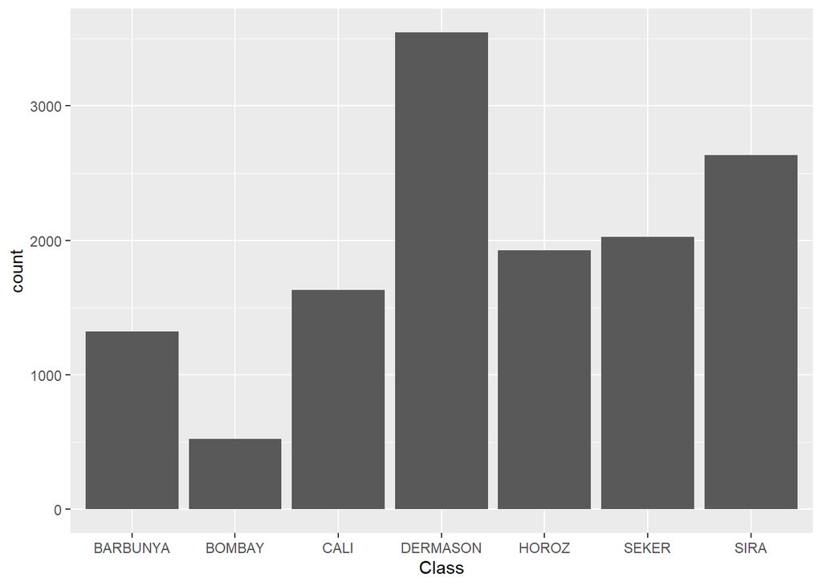

```r
ggplot(data = data, aes(x = Class)) +geom_bar()
```

```r
X = data[,c(1:16)]
y = data[,17]
```

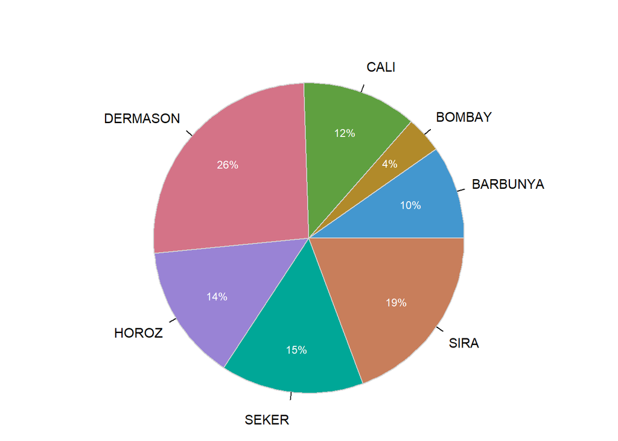

```
## >>> Suggestions
## PieChart(Class, hole=0)  # traditional pie chart
## PieChart(Class, values="%")  # display %'s on the chart
## BarChart(Class)  # bar chart
## Plot(Class)  # bubble plot
## Plot(Class, values="count")  # lollipop plot
##
## --- Class ---
##
##    Class   Count   Prop
## ------------------------
## BARBUNYA    1322   0.097
##   BOMBAY     522   0.038
##     CALI    1630   0.120
## DERMASON    3546   0.261
##    HOROZ    1928   0.142
##    SEKER    2027   0.149
##     SIRA    2636   0.194
## ------------------------
##    Total   13611   1.000
##
## Chi-squared test of null hypothesis of equal probabilities
##   Chisq = 2859.439, df = 6, p-value = 0.000
```

```r
PieChart(Class, hole = 0, values = "%", data = data, main = "")
```

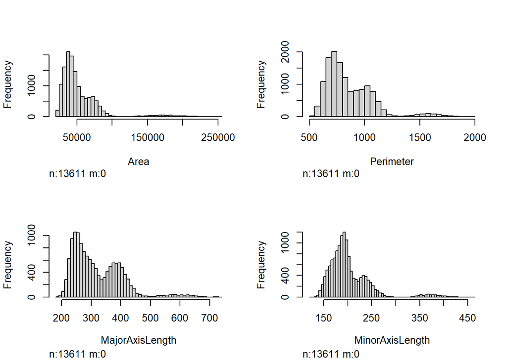

```r
hist.data.frame(X[,c(1:4)])
```

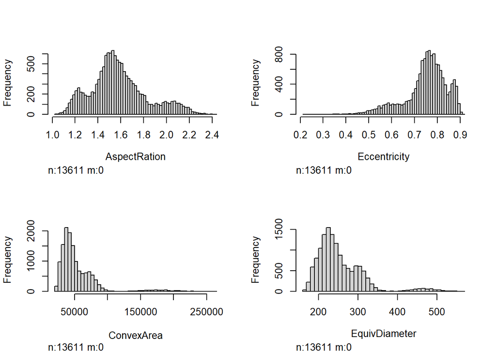

```r
hist.data.frame(X[,c(5:8)])
```

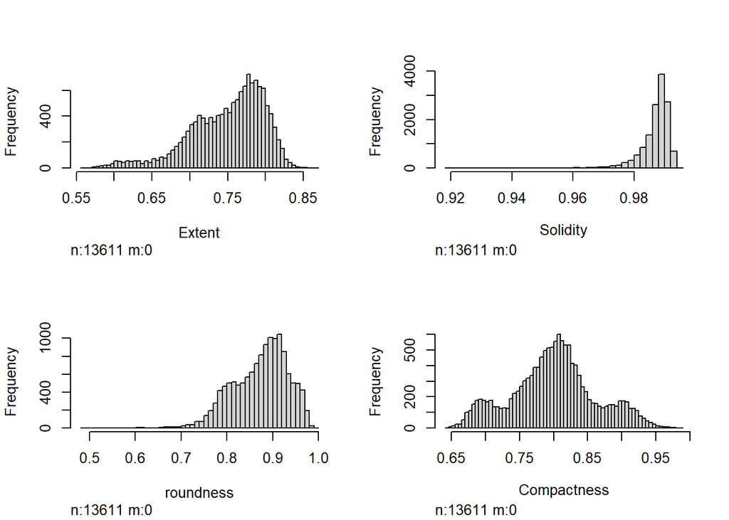

```r
hist.data.frame(X[,c(9:12)])
```

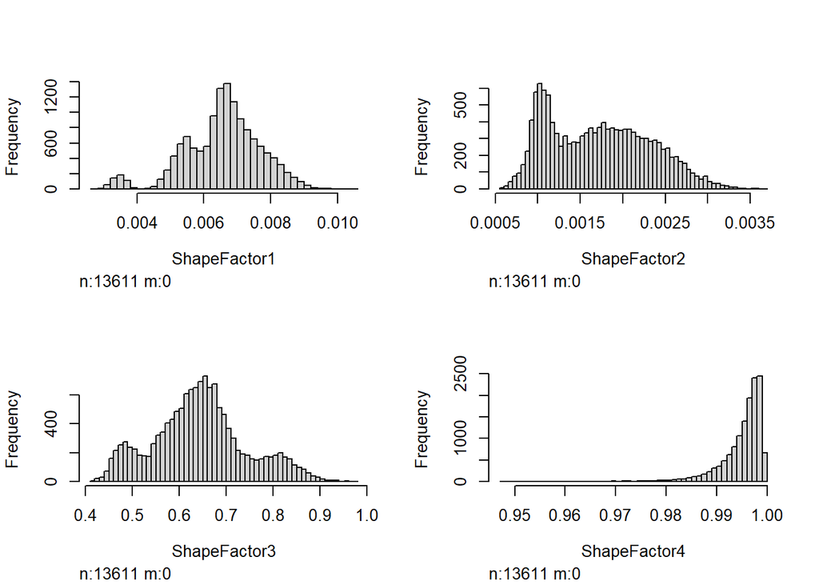

```r
hist.data.frame(X[,c(13:16)])
```

```r
library(GGally)
```

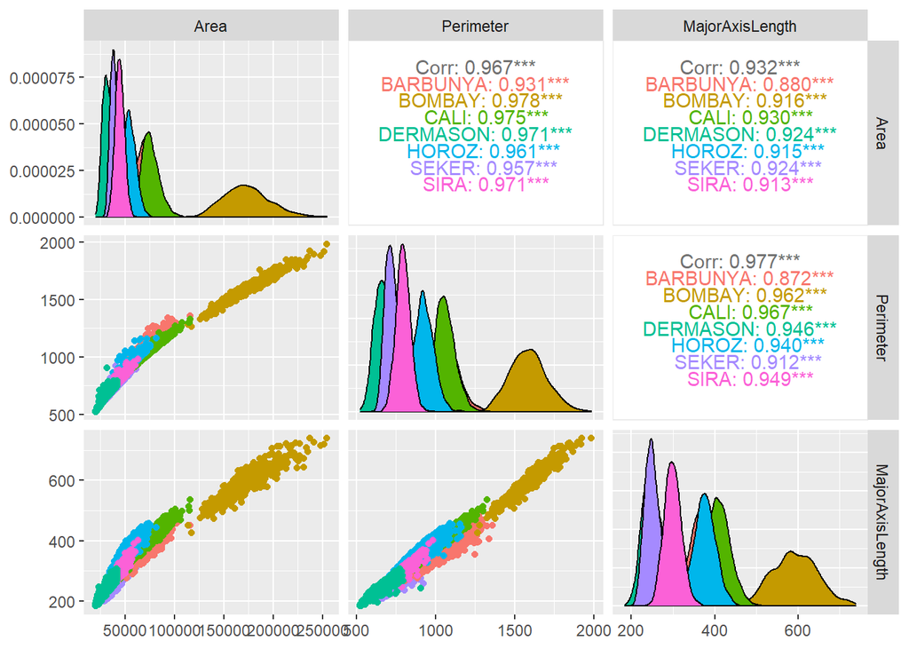

```r
ggpairs(data, columns = 1:3, ggplot2::aes(colour=Class))
```

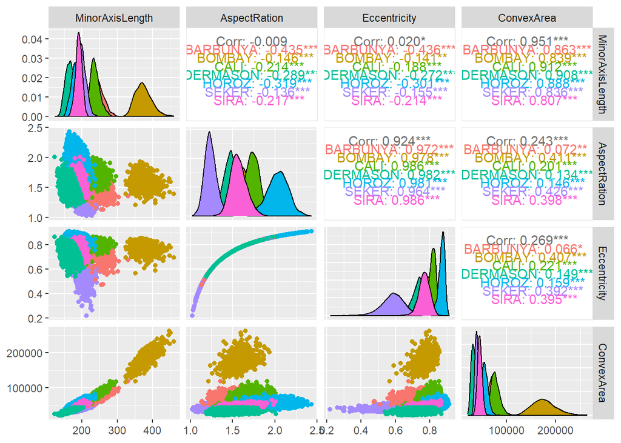

```r
ggpairs(data, columns = 4:7, ggplot2::aes(colour=Class))
```

```r
trainIndex <- createDataPartition(data$Class,p=0.7,list=F)

Train<- data[trainIndex,]
Test <- data[-trainIndex,]

XTrain <- Train[,c(1:16)]
yTrain <- Train[,"Class"]

XTest <- Test[,c(1:16)]
yTest <- Test[,"Class"]


preprocessParams <- preProcess(Train[,c(1:16)], method=c("center","scale"))
XTrain_scaled <- predict(preprocessParams,Train[,c(1:16)])
XTest_scaled <- predict(preprocessParams,Test[,c(1:16)])
```

```r
# Distribution des classes dans les données de Train
print(table(yTrain))
```

```
## yTrain
## BARBUNYA   BOMBAY     CALI DERMASON    HOROZ    SEKER     SIRA
##      926      366     1141     2483     1350     1419     1846
```

```r
# Distribution des classes dans les données de test
print(table(yTest))
```

```
## yTest
## BARBUNYA   BOMBAY     CALI DERMASON    HOROZ    SEKER     SIRA
##      396      156      489     1063      578      608      790
```

## Modèle linéaire pénalisé par une fonction de régularisation elasticnet.

```r
train_control <- trainControl(
  method="cv",
  number=5,
  summaryFunction = multiClassSummary,
  classProbs = TRUE,
)

grid <- expand.grid(
  alpha = seq(0,1,by=0.1),
  lambda = seq(0.0001,0.1,length=20)
)
```

```r
set.seed(42)

glmnet <- train(Class~.,
               data=Train,
               method="glmnet",
               family = "multinomial",
               preProcess = c("center", "scale"),
               tuneGrid = grid,
               metric = "Accuracy",
               trControl = train_control)
```

```r
#print(glmnet)
```

```r
glmnet$bestTune$lambda
```

```
## [1] 0.0001
```

```r
glmnet$bestTune$alpha
```

```
## [1] 1
```

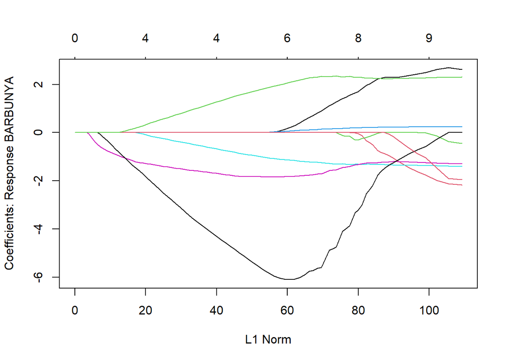

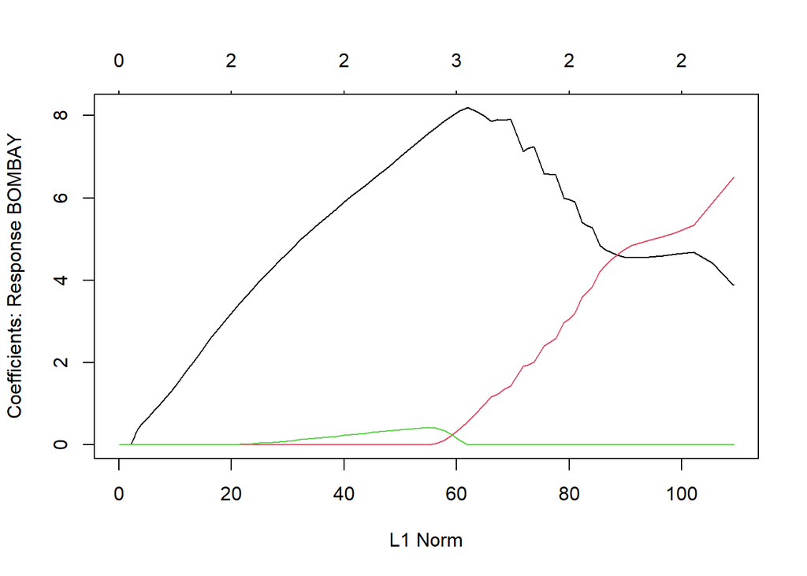

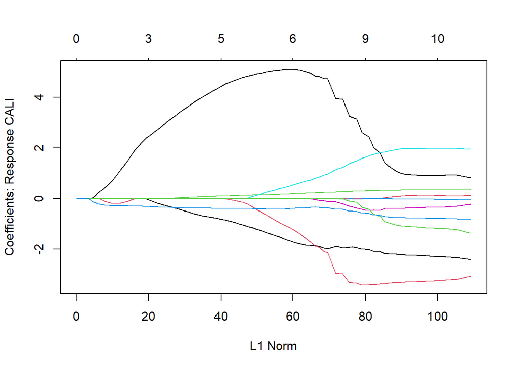

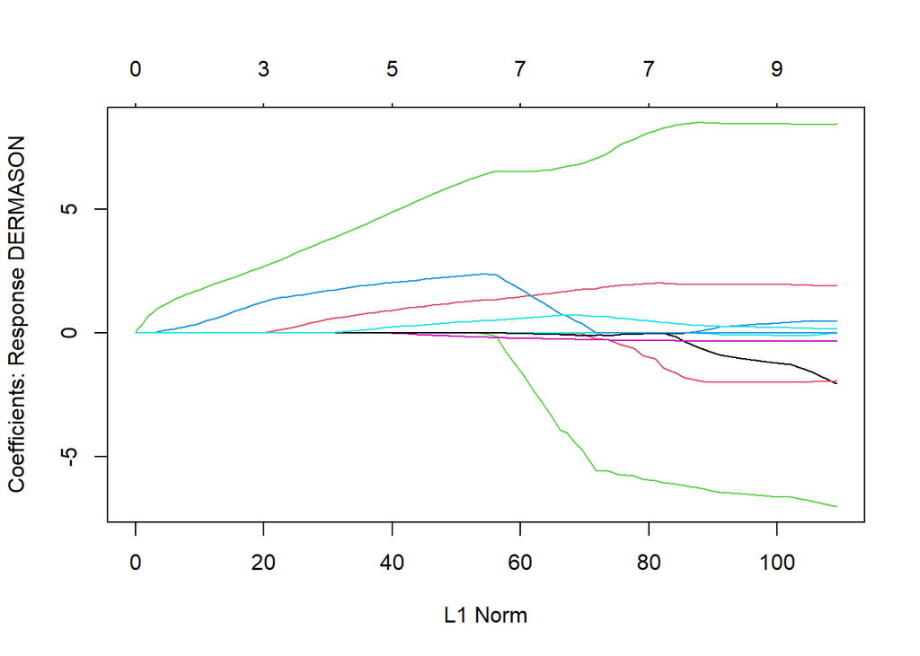

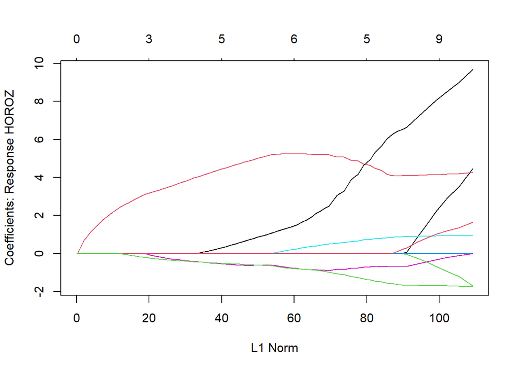

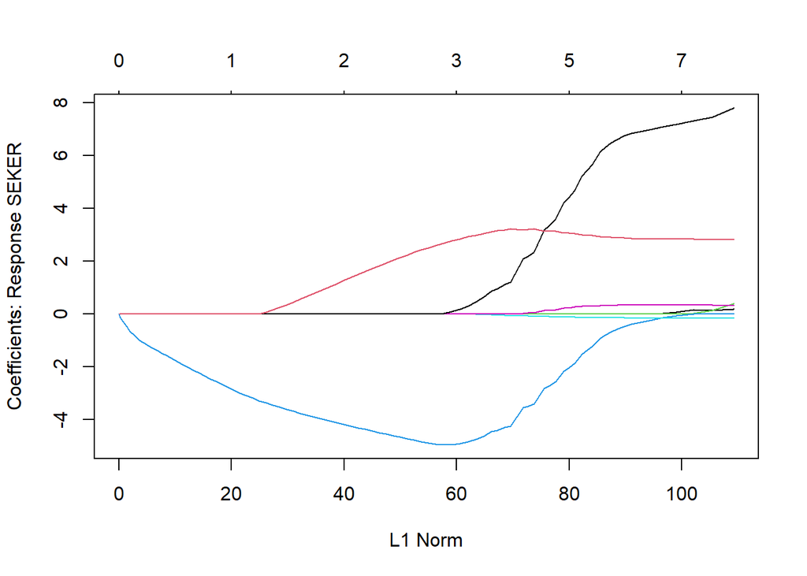

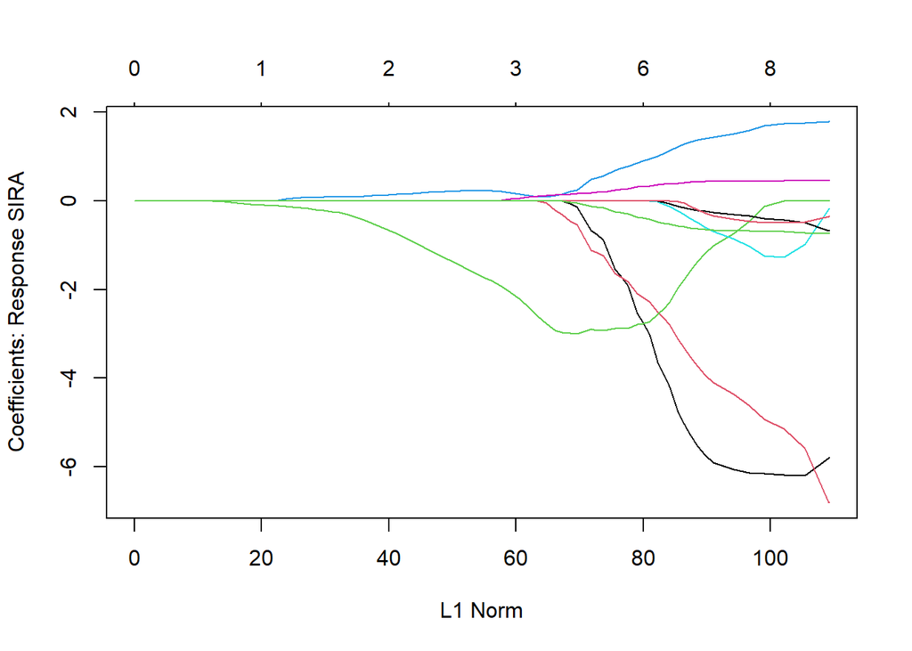

```r
plot(glmnet$finalModel)
```

```r
pred <- predict(glmnet,newdata = XTest)
```

```r
cm_glmnet = confusionMatrix(as.factor(pred), Test$Class, positive = NULL, dnn = c("Prediction", "Reference"))
cm_glmnet
```

```
## Confusion Matrix and Statistics
##
##           Reference
## Prediction BARBUNYA BOMBAY CALI DERMASON HOROZ SEKER SIRA
##   BARBUNYA      358      0   11        1     1     7    0
##   BOMBAY          0    156    0        0     0     0    0
##   CALI           23      0  469        0    16     0    2
##   DERMASON        0      0    0      973     7    12   86
##   HOROZ           0      0    7        1   545     0   13
##   SEKER           6      0    2       20     0   573   16
##   SIRA            9      0    0       68     9    16  673
##
## Overall Statistics
##
##                Accuracy : 0.9184
##                  95% CI : (0.9096, 0.9266)
##     No Information Rate : 0.2605
##     P-Value [Acc > NIR] : < 0.00000000000000022
##
##                   Kappa : 0.9013
##
##  Mcnemar's Test P-Value : NA
##
## Statistics by Class:
##
##                      Class: BARBUNYA Class: BOMBAY Class: CALI Class: DERMASON
## Sensitivity                  0.90404       1.00000      0.9591          0.9153
## Specificity                  0.99457       1.00000      0.9886          0.9652
## Pos Pred Value               0.94709       1.00000      0.9196          0.9026
## Neg Pred Value               0.98974       1.00000      0.9944          0.9700
## Prevalence                   0.09706       0.03824      0.1199          0.2605
## Detection Rate               0.08775       0.03824      0.1150          0.2385
## Detection Prevalence         0.09265       0.03824      0.1250          0.2642
## Balanced Accuracy            0.94931       1.00000      0.9738          0.9403
##                      Class: HOROZ Class: SEKER Class: SIRA
## Sensitivity                0.9429       0.9424      0.8519
## Specificity                0.9940       0.9873      0.9690
## Pos Pred Value             0.9629       0.9287      0.8684
## Neg Pred Value             0.9906       0.9899      0.9646
## Prevalence                 0.1417       0.1490      0.1936
## Detection Rate             0.1336       0.1404      0.1650
## Detection Prevalence       0.1387       0.1512      0.1900
## Balanced Accuracy          0.9685       0.9649      0.9104
```

```r
prob = predict(glmnet, newdata = XTest,type="prob")
auc_glm = multiclass.roc(yTest~as.matrix(prob),plot=FALSE)

# Accuracy
accuracy_glm = cm_glmnet$overall['Accuracy']
accuracy_class_glm = cm_glmnet[["byClass"]][ , "Balanced Accuracy"]
#F1_score
f1_glm=F1_Score(yTest, pred, positive = NULL)
```

```r
print(auc_glm)
```

```
##
## Call:
## multiclass.roc.formula(formula = yTest ~ as.matrix(prob), plot = FALSE)
##
## Data: multivariate predictor as.matrix(prob) with 7 levels of yTest: BARBUNYA, BOMBAY, CALI, DERMASON, HOROZ, SEKER, SIRA.
## Multi-class area under the curve: 0.9952
```

```r
print(accuracy_glm)
```

```
##  Accuracy
## 0.9183824
```

```r
print(f1_glm)
```

```
## [1] 0.9250646
```

## SVM

```r
## Ne pas exécuter
## Le meilleur modèle est C = 7 et kernel = radial

# tuned = tune(svm,train.x=as.matrix(XTrain_scaled),
# train.y=yTrain, data = data,
# scale=F, type = "C-classification",
# ranges = list(cost=seq(0.1, 10, 0.1),kernel= c("linear","radial","sigmoid","polynomial")),
# tunecontrol=tune.control(cross=10))
# tuned$performances
```

```r
svm = svm(as.matrix(XTrain), yTrain, scale=T, type= "C-classification",kernel='radial',cost = 7,probability = TRUE)
```

```r
pred = predict(svm, newdata = as.matrix(XTest),probability = TRUE)
auc_svm = multiclass.roc(yTest~attr(pred,"probabilities"),plot=FALSE)

#Matrice de confusion
cm = confusionMatrix(as.factor(pred), Test$Class, positive = NULL, dnn = c("Prediction", "Reference"))
print(cm)
```

```
## Confusion Matrix and Statistics
##
##           Reference
## Prediction BARBUNYA BOMBAY CALI DERMASON HOROZ SEKER SIRA
##   BARBUNYA      363      0   10        0     2     1    3
##   BOMBAY          0    156    0        0     0     0    0
##   CALI           19      0  468        0     9     0    2
##   DERMASON        0      0    0      994     7    14   90
##   HOROZ           0      0    9        1   548     0    7
##   SEKER           7      0    2       19     0   576   12
##   SIRA            7      0    0       49    12    17  676
##
## Overall Statistics
##
##                Accuracy : 0.9267
##                  95% CI : (0.9183, 0.9345)
##     No Information Rate : 0.2605
##     P-Value [Acc > NIR] : < 0.00000000000000022
##
##                   Kappa : 0.9113
##
##  Mcnemar's Test P-Value : NA
##
## Statistics by Class:
##
##                      Class: BARBUNYA Class: BOMBAY Class: CALI Class: DERMASON
## Sensitivity                  0.91667       1.00000      0.9571          0.9351
## Specificity                  0.99566       1.00000      0.9916          0.9632
## Pos Pred Value               0.95778       1.00000      0.9398          0.8995
## Neg Pred Value               0.99108       1.00000      0.9941          0.9768
## Prevalence                   0.09706       0.03824      0.1199          0.2605
## Detection Rate               0.08897       0.03824      0.1147          0.2436
## Detection Prevalence         0.09289       0.03824      0.1221          0.2708
## Balanced Accuracy            0.95616       1.00000      0.9744          0.9491
##                      Class: HOROZ Class: SEKER Class: SIRA
## Sensitivity                0.9481       0.9474      0.8557
## Specificity                0.9951       0.9885      0.9742
## Pos Pred Value             0.9699       0.9351      0.8883
## Neg Pred Value             0.9915       0.9908      0.9657
## Prevalence                 0.1417       0.1490      0.1936
## Detection Rate             0.1343       0.1412      0.1657
## Detection Prevalence       0.1385       0.1510      0.1865
## Balanced Accuracy          0.9716       0.9679      0.9149
```

```r
accuracy_svm = cm$overall['Accuracy']
accuracy_class_svm = cm[["byClass"]][ , "Balanced Accuracy"]
# F1 score
f1_svm=F1_Score(yTest, pred, positive = NULL)
```

## RESEAU DE NEURONES

```r
y <- as.factor(make.names(Train$Class))
```

```r
XTrain_scaled$y <- y
```

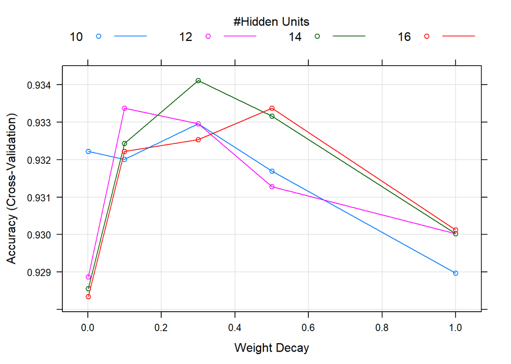

```r
ctrl  <- trainControl(method  = "cv",number  = 5,
                     summaryFunction = multiClassSummary, # Multiple metrics
                     classProbs=T,# Required for the ROC curves
                     savePredictions = T,
                     )

set.seed(150)

mygrid <- expand.grid(.decay = c(1, 0.5, 0.3, 0.1, 0.001), .size = c(10, 12, 14,16))
#decay is the regularization parameter to avoid over-fitting

fit.mlp <- train(y~.-y, data = XTrain_scaled,
                 method = "nnet",
                 trControl = ctrl,
                 act.fct= "logistic",
                 maxit = 250,    # Maximum number of iterations
                 tuneGrid = mygrid, #data.frame(size = 10, decay = 0),
                 metric = "Accuracy", linout = FALSE)
plot(fit.mlp)
```

```r
prob_cv <- predict(fit.mlp, newdata=XTest_scaled,type = "prob")

# Classes prédites :
y_pred = prob_cv %>% mutate('class'=names(.)[apply(., 1, which.max)])
head(prob_cv)
```

|  | BARBUNYA | BOMBAY | CALI | DERMASON | HOROZ | SEKER | SIRA |
| --- | --- | --- | --- | --- | --- | --- | --- |
| 4 | 0.0040797224702 | 0.000248813371 | 0.0001201908905 | 0.663938714 | 0.001304388061 | 0.32536621 | 0.004941962481 |
| 5 | 0.0000006171097 | 0.000018869534 | 0.0000000325848 | 0.000798071 | 0.000002839677 | 0.99917438 | 0.000005192547 |
| 7 | 0.0003577114997 | 0.000028473609 | 0.0000231122085 | 0.001218200 | 0.000010750815 | 0.99818379 | 0.000177965173 |
| 17 | 0.0000172648073 | 0.000062204178 | 0.0000002985236 | 0.004501641 | 0.000010438290 | 0.99521327 | 0.000194886551 |
| 24 | 0.0000489033365 | 0.000102906489 | 0.0000016409159 | 0.769678202 | 0.000609525007 | 0.20505040 | 0.024508424712 |
| 25 | 0.0000001234892 | 0.000003866187 | 0.0000009499523 | 0.992453602 | 0.000666960410 | 0.00115811 | 0.005716388436 |

```r
#Matrice de confusion :
y_test= as.factor(unlist(yTest))
conf2 <- confusionMatrix(as.factor(y_pred$class), Test$Class)
conf2
```

```
## Confusion Matrix and Statistics
##
##           Reference
## Prediction BARBUNYA BOMBAY CALI DERMASON HOROZ SEKER SIRA
##   BARBUNYA      364      1    9        1     1     3    4
##   BOMBAY          0    155    0        0     0     0    0
##   CALI           20      0  471        0    12     1    1
##   DERMASON        0      0    0     1000     7    14   93
##   HOROZ           0      0    7        0   550     0   11
##   SEKER           7      0    2       15     0   574   13
##   SIRA            5      0    0       47     8    16  668
##
## Overall Statistics
##
##                Accuracy : 0.927
##                  95% CI : (0.9185, 0.9348)
##     No Information Rate : 0.2605
##     P-Value [Acc > NIR] : < 0.00000000000000022
##
##                   Kappa : 0.9116
##
##  Mcnemar's Test P-Value : NA
##
## Statistics by Class:
##
##                      Class: BARBUNYA Class: BOMBAY Class: CALI Class: DERMASON
## Sensitivity                  0.91919       0.99359      0.9632          0.9407
## Specificity                  0.99484       1.00000      0.9905          0.9622
## Pos Pred Value               0.95039       1.00000      0.9327          0.8977
## Neg Pred Value               0.99134       0.99975      0.9950          0.9788
## Prevalence                   0.09706       0.03824      0.1199          0.2605
## Detection Rate               0.08922       0.03799      0.1154          0.2451
## Detection Prevalence         0.09387       0.03799      0.1238          0.2730
## Balanced Accuracy            0.95702       0.99679      0.9769          0.9515
##                      Class: HOROZ Class: SEKER Class: SIRA
## Sensitivity                0.9516       0.9441      0.8456
## Specificity                0.9949       0.9893      0.9769
## Pos Pred Value             0.9683       0.9394      0.8978
## Neg Pred Value             0.9920       0.9902      0.9634
## Prevalence                 0.1417       0.1490      0.1936
## Detection Rate             0.1348       0.1407      0.1637
## Detection Prevalence       0.1392       0.1498      0.1824
## Balanced Accuracy          0.9732       0.9667      0.9112
```

```r
#F1_score
f1_nn = F1_Score(y_test, y_pred$class, positive = NULL)

# Accuracy
accuracy_nn = conf2$overall['Accuracy']
accuracy_class_nn = conf2[["byClass"]][ , "Balanced Accuracy"]

#AUC

auc_nn = multiclass.roc(y_test , prob_cv, levels=levels(y_test))
auc_nn
```

```
##
## Call:
## multiclass.roc.default(response = y_test, predictor = prob_cv,     levels = levels(y_test))
##
## Data: multivariate predictor prob_cv with 7 levels of y_test: BARBUNYA, BOMBAY, CALI, DERMASON, HOROZ, SEKER, SIRA.
## Multi-class area under the curve: 0.9961
```

```r
# AUC = 0.996
```

```r
model_scores =  c(auc_svm$auc,auc_nn$auc,auc_glm$auc,accuracy_svm,accuracy_nn,accuracy_glm,f1_svm,f1_nn,f1_glm)
model_scores2 = c(accuracy_class_glm,accuracy_class_svm,accuracy_class_nn)
```

```r
models = c("SVM","Neurones","RL pénalisée","SVM","Neurones","RL pénalisée","SVM","Neurones","RL pénalisée")
```

```r
metrics = c("AUC", "AUC", "AUC","Accuracy","Accuracy","Accuracy","F1-Score","F1-Score","F1-Score")
```

```r
comparaison = data.frame(models,metrics,model_scores)
comparaison = comparaison[order(models),]


comparaison_class = data.frame(modèles=c(rep("RL_Pénalisée",7),rep("SVM",7),rep("Neurones",7)),espèces = rep(levels(yTest),3),accuracy=model_scores2)

comparaison_class
```

| modèles | espèces | accuracy |
| --- | --- | --- |
| RL_Pénalisée | BARBUNYA | 0.9493058 |
| RL_Pénalisée | BOMBAY | 1.0000000 |
| RL_Pénalisée | CALI | 0.9738414 |
| RL_Pénalisée | DERMASON | 0.9402656 |
| RL_Pénalisée | HOROZ | 0.9684550 |
| RL_Pénalisée | SEKER | 0.9648807 |
| RL_Pénalisée | SIRA | 0.9104478 |
| SVM | BARBUNYA | 0.9561618 |
| SVM | BOMBAY | 1.0000000 |
| SVM | CALI | 0.9743505 |

[output cut: 11 more lines]

```r
accuracy_class_glm
```

```
## Class: BARBUNYA   Class: BOMBAY     Class: CALI Class: DERMASON    Class: HOROZ
##       0.9493058       1.0000000       0.9738414       0.9402656       0.9684550
##    Class: SEKER     Class: SIRA
##       0.9648807       0.9104478
```

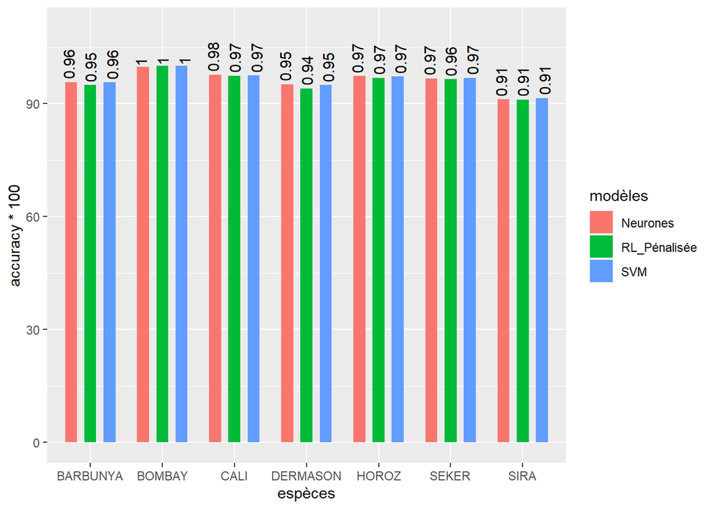

```r
ggplot(comparaison_class,aes(fill=modèles,y=accuracy*100,x=espèces)) +
    geom_bar(position=position_dodge(width=0.8),stat = "identity",width = 0.5) +
    geom_text(aes(label=round(accuracy,digits = 2)),angle=90,position=position_dodge(width=0.9),hjust=-0.1) +
    scale_y_continuous(limits = c(0,110))
```

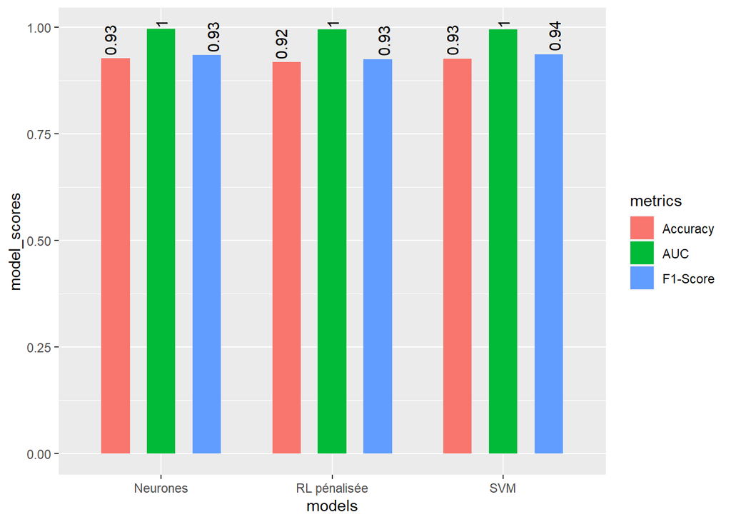

```r
ggplot(comparaison,aes(fill=metrics,y=model_scores,x=models)) +
    geom_bar(position=position_dodge(width=0.8),stat = "identity",width = 0.5) +
    geom_text(aes(label=round(model_scores,digits=2)),angle=90,position=position_dodge(width=0.9),hjust=-0.1)
```